# STAT 420: Homework 10

Fall 2020, Sahana Epari, NetID: epari2

Due: Tuesday, November 17 by 11:30 PM CT

# Assignment

## Exercise 1 (TV Is Healthy?)

For this exercise we will use the `tvdoctor` data, which can be found in the `faraway` package. After loading the `faraway` package, use `?tvdoctor` to learn about this dataset.

```r
library(faraway)
?tvdoctor
```

**(a)** Fit a simple linear regression with `life` as the response and `tv` as the predictor. Plot a scatterplot and add the fitting line. Check the assumptions of this model.

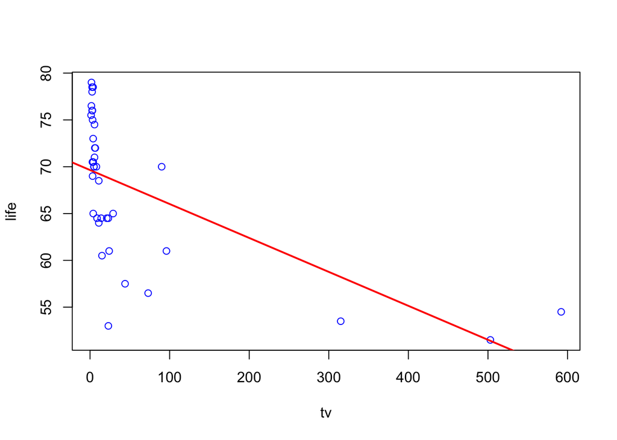

```r
model = lm(life~tv,data=tvdoctor)
plot(life~tv,data=tvdoctor,col="blue")
abline(model,col="red",lwd=2)
```

Assumptions: 1. Linearity and Constant Variance

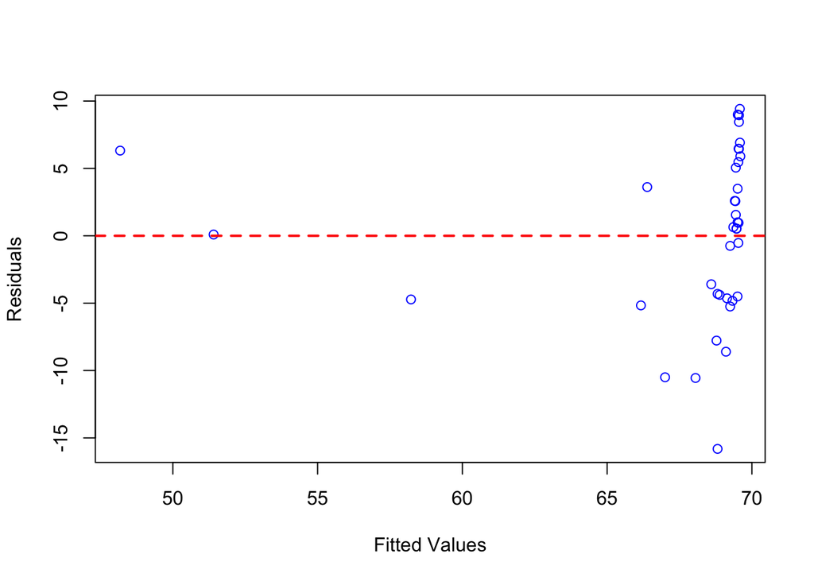

```r
plot(fitted(model),resid(model),col="blue",xlab = "Fitted Values", ylab="Residuals")
abline(h=0,lty=2,col="red",lwd=2)
```

Neither assumption is true because the mean of the residuals is not 0 and the spread is not the same for all fitted points.

2. Normality of errors

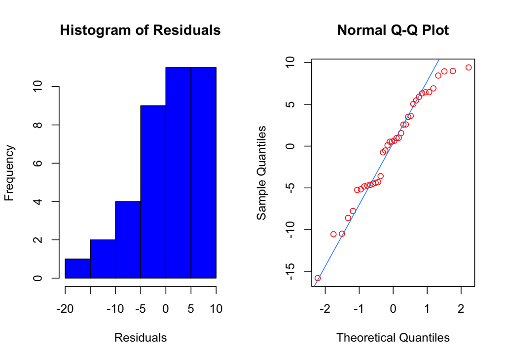

```r
par(mfrow=c(1,2))
hist(resid(model),xlab="Residuals",col="blue", main="Histogram of Residuals")
qqnorm(resid(model),main="Normal Q-Q Plot",col="red")
qqline(resid(model),col="dodgerblue")
```

As shown, the errors are not normally distributed.

**(b)** Fit higher order polynomial models of degree 3, 5, and 7. For each, plot a fitted versus residuals plot and comment on the constant variance assumption. Based on those plots, which of these three models do you think are acceptable? Use a statistical test(s) to compare the models you just chose. Based on the test, which is preferred? Check the normality assumption of this model. Identify any influential observations of this model.

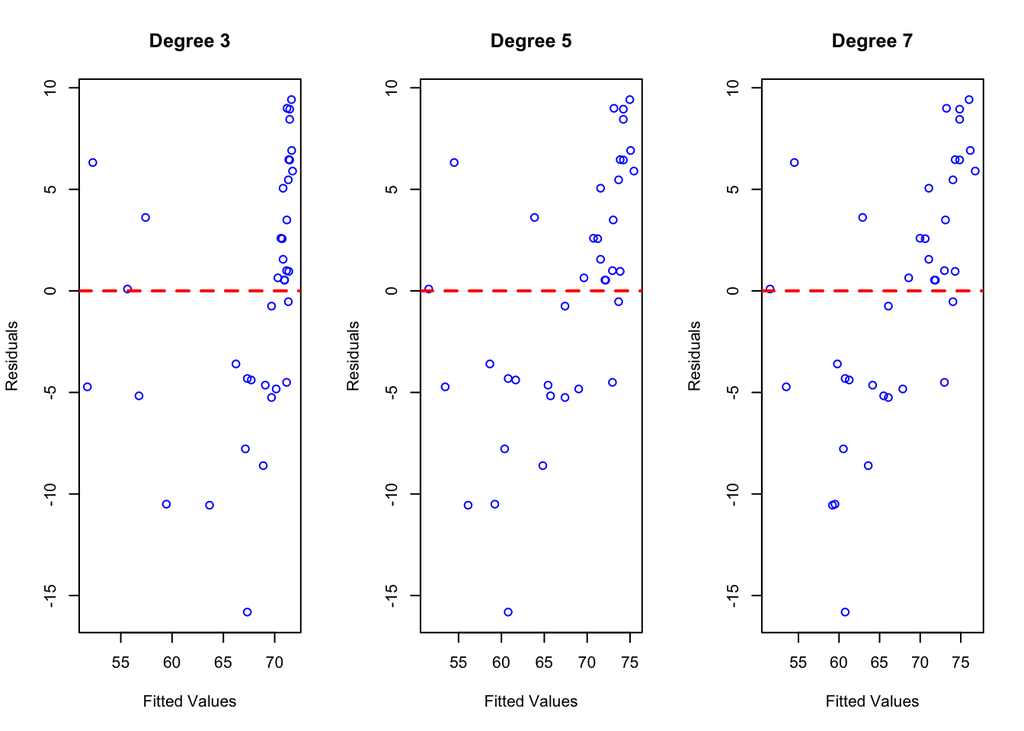

```r
fit3 = lm(life~tv + I(tv^2)+ I(tv^3),data=tvdoctor)
fit5 = lm(life~tv + I(tv^2)+ I(tv^3) + I(tv^4) + I(tv^5),data=tvdoctor)
fit7 = lm(life~tv + I(tv^2)+ I(tv^3) + I(tv^4) + I(tv^5) + I(tv^6) + I(tv^7),data=tvdoctor)

par(mfrow=c(1,3))
plot(fitted(fit3),resid(model),col="blue",xlab = "Fitted Values", ylab="Residuals", main="Degree 3")
abline(h=0,lty=2,col="red",lwd=2)
plot(fitted(fit5),resid(model),col="blue",xlab = "Fitted Values", ylab="Residuals",main="Degree 5")
abline(h=0,lty=2,col="red",lwd=2)
plot(fitted(fit7),resid(model),col="blue",xlab = "Fitted Values", ylab="Residuals",main="Degree 7")
abline(h=0,lty=2,col="red",lwd=2)
```

The fifth degree and seventh degree follows the constant variance assumption.

```r
anova(fit5,fit7)
```

```
## Analysis of Variance Table
##
## Model 1: life ~ tv + I(tv^2) + I(tv^3) + I(tv^4) + I(tv^5)
## Model 2: life ~ tv + I(tv^2) + I(tv^3) + I(tv^4) + I(tv^5) + I(tv^6) +
##     I(tv^7)
##   Res.Df RSS Df Sum of Sq    F Pr(>F)
## 1     32 457
## 2     30 428  2      28.9 1.01   0.38
```

Due to a high p-value of 0.38, we can say that the fifth degree fit is a better option.

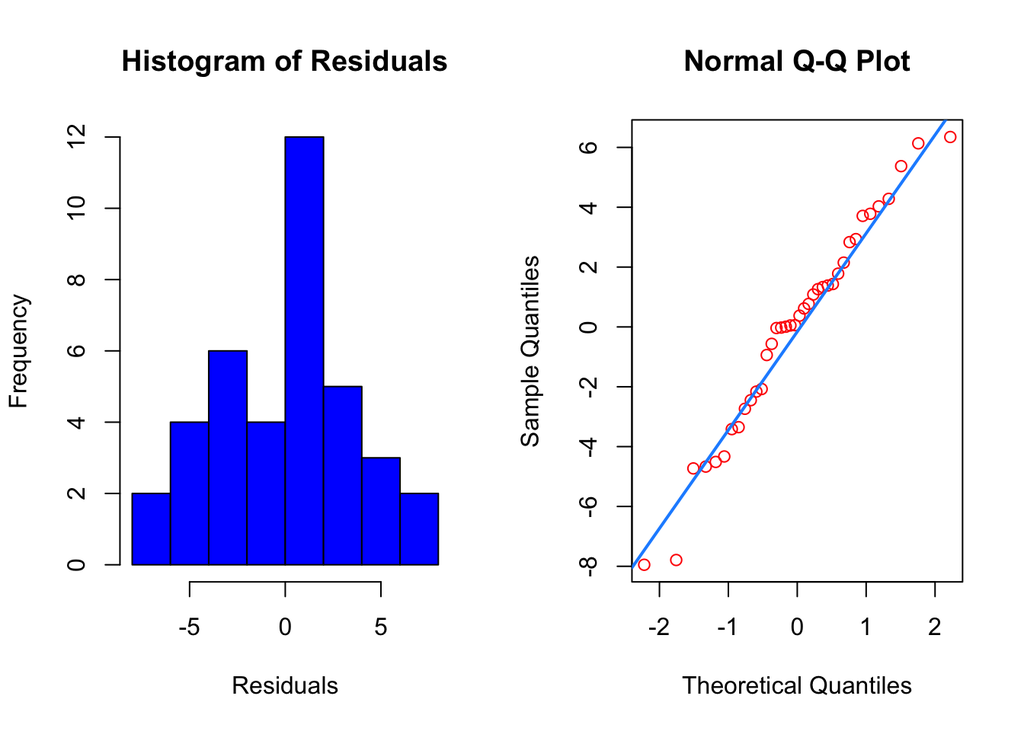

```r
par(mfrow=c(1,2))
hist(resid(fit5), xlab="Residuals",main="Histogram of Residuals",col="blue")
qqnorm(resid(fit5),main="Normal Q-Q Plot",col="red")
qqline(resid(fit5),col="dodgerblue",lwd=2)
```

Here the histogram appears to be normal.

```r
tvdoctor[cooks.distance(fit5)>4 / length(cooks.distance(fit5)),]
```

```
##            life  tv doctor
## Bangladesh 53.5 315   6166
## Ethiopia   51.5 503  36660
## Kenya      61.0  96   7615
## KoreaNorth 70.0  90    370
## Myanmar    54.5 592   3485
```

There are multiple influential points.

## Exercise 2 (Brains)

The data set `mammals` from the `MASS` package contains the average body weight in kilograms $(x)$ and the average brain weight in grams $(y)$ for $62$ species of land mammals. Use `?mammals` to learn more.

```r
library(MASS)
```

**(a)** What are the smallest and largest body weights in the dataset?

```r
min(mammals$body)
```

```
## [1] 0.005
```

```r
max(mammals$body)
```

```
## [1] 6654
```

**(b)** What are the smallest and largest brain weights in the dataset?

```r
min(mammals$brain)
```

```
## [1] 0.14
```

```r
max(mammals$brain)
```

```
## [1] 5712
```

**(c)** Plot average brain weight $(y)$ versus average body weight $(x)$.

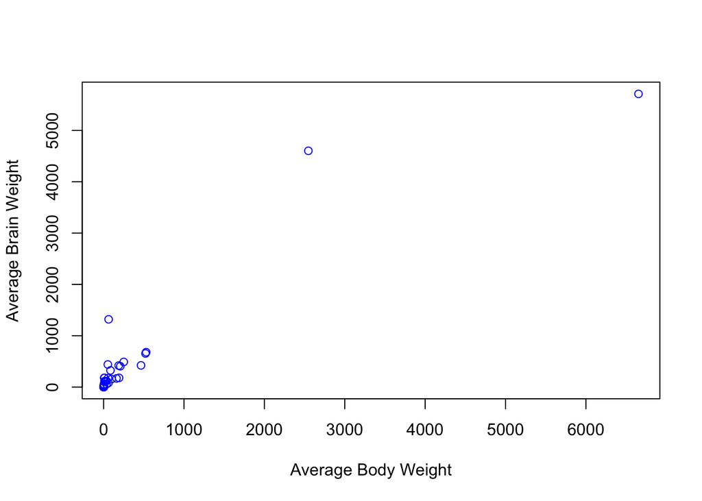

```r
plot(brain ~ body, data=mammals, col = "blue", xlab = "Average Body Weight",ylab = "Average Brain Weight")
```

**(d)** Fit a linear model with `brain` as the response and `body` as the predictor. Test for significance of regression. Do you think this is an appropriate model?

Recall, *the log rule*: if the values of a variable range over more than one order of magnitude and the variable is strictly positive, then replacing the variable by its logarithm is likely to be helpful.

*Linear Model*

```r
mammalfit = lm(brain~body,data=mammals)
summary(mammalfit)
```

```
##
## Call:
## lm(formula = brain ~ body, data = mammals)
##
## Residuals:
##    Min     1Q Median     3Q    Max
## -810.1  -88.5  -79.6  -13.0 2050.3
##
## Coefficients:
##             Estimate Std. Error t value Pr(>|t|)
## (Intercept)  91.0044    43.5526    2.09    0.041 *
## body          0.9665     0.0477   20.28   <2e-16 ***
## ---
## Signif. codes:  0 '***' 0.001 '**' 0.01 '*' 0.05 '.' 0.1 ' ' 1
##
## Residual standard error: 335 on 60 degrees of freedom
## Multiple R-squared:  0.873,  Adjusted R-squared:  0.871
## F-statistic:  411 on 1 and 60 DF,  p-value: <2e-16
```

The regression is significant due to the low p-value.

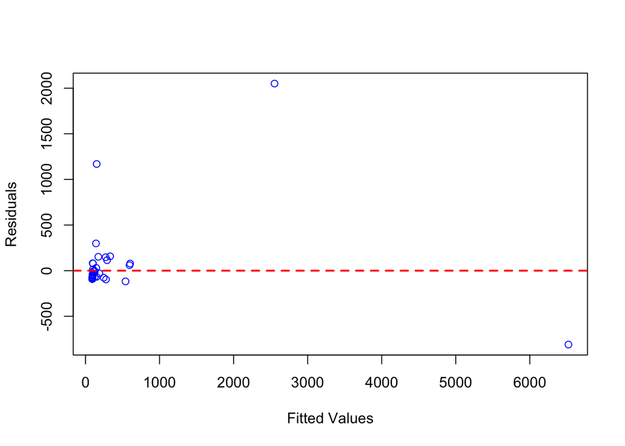

```r
plot(fitted(mammalfit),resid(mammalfit),col="blue",xlab="Fitted Values",ylab="Residuals")
abline(h=0,lty=2,col="red",lwd=2)
```

The constant variation and linearity assumption is not supported with this data.

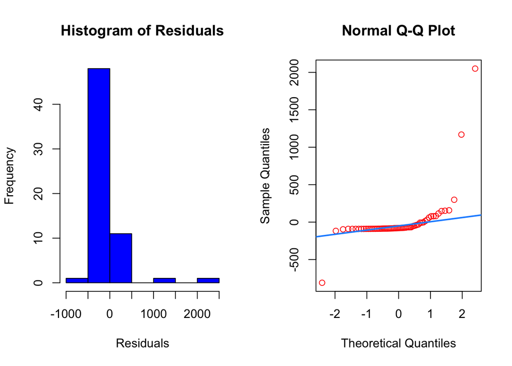

```r
par(mfrow=c(1,2))
hist(resid(mammalfit), xlab="Residuals",main="Histogram of Residuals",col="blue")
qqnorm(resid(mammalfit),main="Normal Q-Q Plot",col="red")
qqline(resid(mammalfit),col="dodgerblue",lwd=2)
```

Normality of error assumption is also violated. The model is not appropriate for the data.

*Log Model*

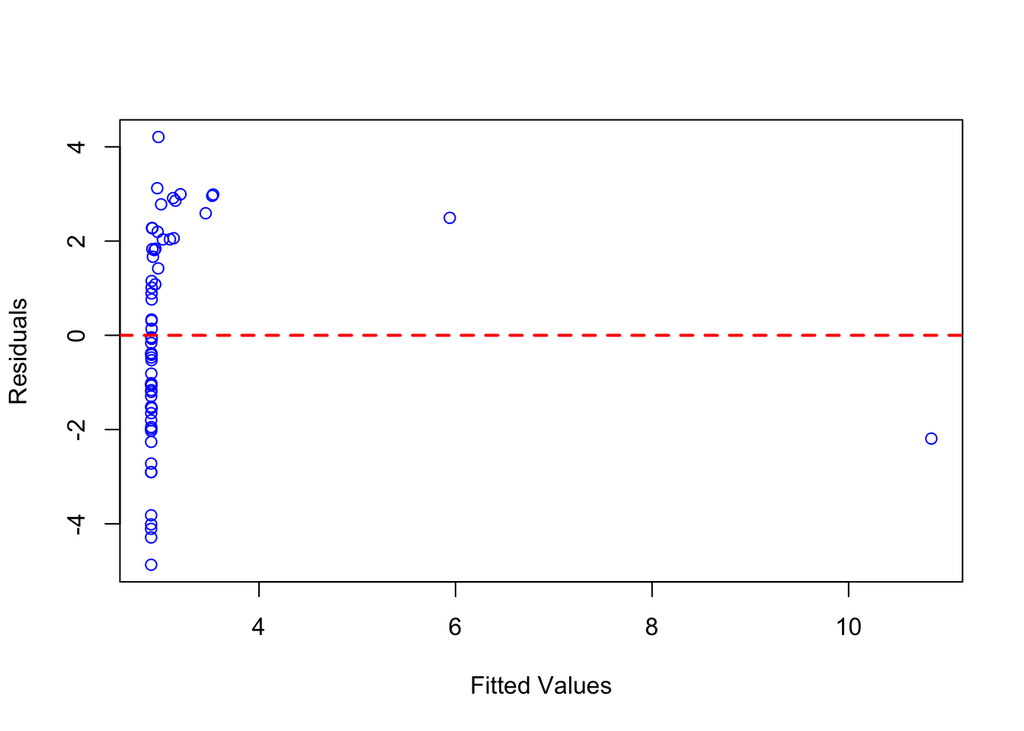

```r
logfit = lm(log(brain)~body,data=mammals)
plot(fitted(logfit),resid(logfit),col="blue",xlab="Fitted Values",ylab="Residuals")
abline(h=0,lty=2,col="red",lwd=2)
```

**(e)** Since the body weights do range over more than one order of magnitude and are strictly positive, we will use $\log(\text{body weight})$ as our *predictor*, with no further justification. Use the Box-Cox method to verify that $\log(\text{brain weight})$ is then a “recommended” transformation of the *response* variable. That is, verify that $\lambda = 0$ is among the “recommended” values of $\lambda$ when considering,

$$g_\lambda(y) = \beta_0 + \beta_1 \log(\text{body weight})+\epsilon$$

Please include the relevant plot in your results, using an appropriate zoom onto the relevant values.

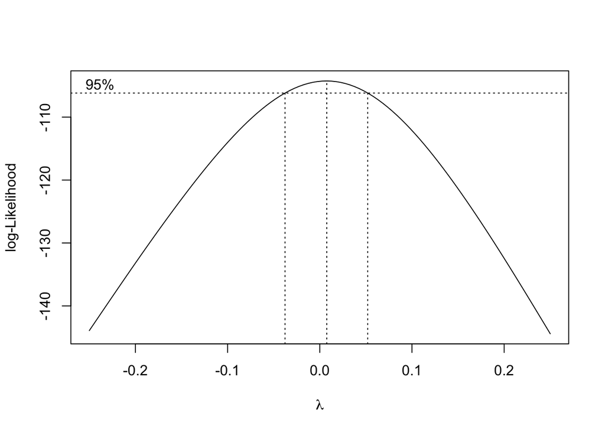

```r
model = lm(brain~log(body),data=mammals)
boxcox(model,lambda = seq(-0.25,0.25,by=0.05),plotit=TRUE)
```

As shown, `λ = 0` is among the recommended values of $\lambda$.

**(f)** Fit the model justified in part **(e)**. That is, fit a model with $\log(\text{brain weight})$ as the response and $\log(\text{body weight})$ as a predictor. Plot $\log(\text{brain weight})$ versus $\log(\text{body weight})$ and add the regression line to the plot. Does a linear relationship seem to be appropriate here?

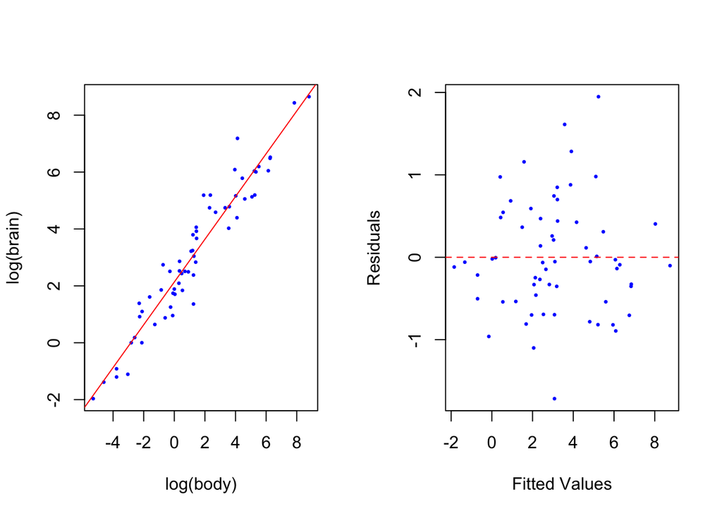

```r
par(mfrow=c(1,2))
model2 = lm(log(brain)~log(body),data=mammals)
plot(log(brain) ~ log(body), data = mammals, col = "blue", pch = 20, cex = .5 )
abline(model2, col = "red")
plot(fitted(model2), resid(model2), col = "blue", pch = 20, cex = .5, xlab = "Fitted Values", ylab = "Residuals")
abline(h = 0, lty = 2, col = "red")
```

A linear relationship does seem to be appropriate in this case.

**(g)** Use a Q-Q plot to check the normality of the errors for the model fit in part **(f)**.

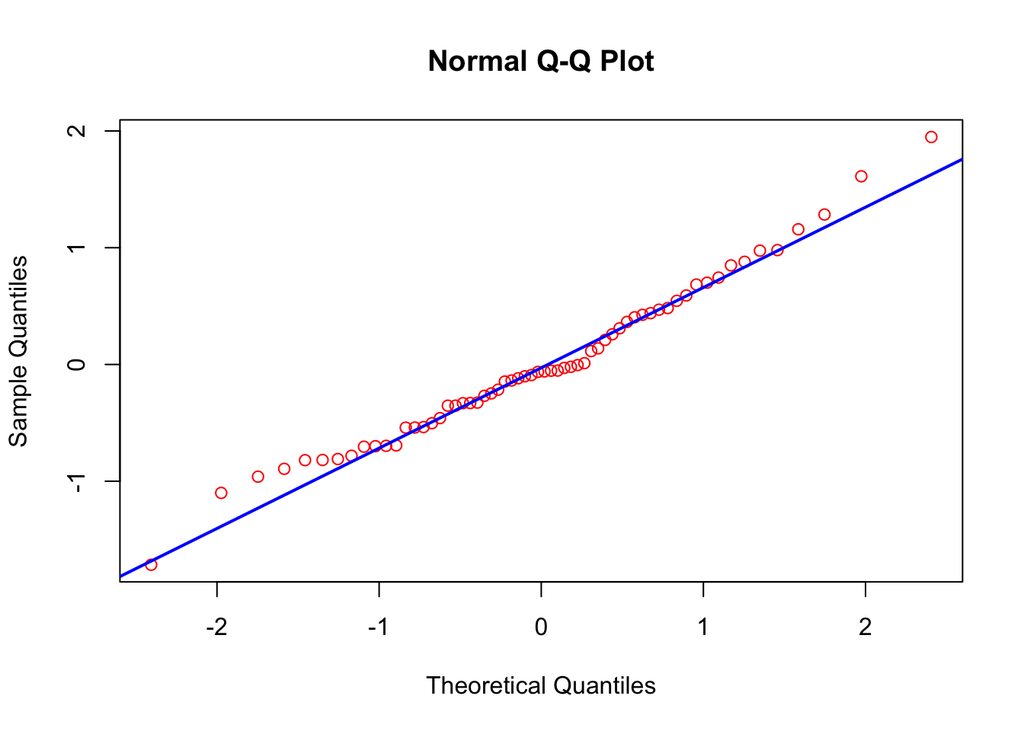

```r
qqnorm(resid(model2), main = "Normal Q-Q Plot", col = "red")
qqline(resid(model2), col = "blue", lwd = 2)
```

The Q-Q plot suggests that the normality assumption is not violated.

**(h)** Use the model from part **(f)** to predict the brain weight of a male Pikachu which, has a body weight of 13.4 pounds. (Pikachu would be mammals, right?) Construct a 99% prediction interval.

```r
pikachu  = data.frame(body = 13.4)
exp(predict(model2, pikachu, interval="prediction",level=0.99))
```

```
##     fit   lwr   upr
## 1 59.48 9.219 383.7
```

## Exercise 3 (EPA Emissions Data, Redux)

For this exercise we will again use the data stored in `epa2015.csv`. It contains detailed descriptions of 4,411 vehicles manufactured in 2015 that were used for fuel economy testing [as performed by the Environment Protection Agency](https://www3.epa.gov/otaq/tcldata.htm).

**(a)** Recall the model we had finished with last time:

```r
epa2015 = read.csv("epa2015.csv")
epa2015$type = as.factor(epa2015$type)
co2_int = lm(CO2 ~ horse * type, data = epa2015)
```

Which looked like this:

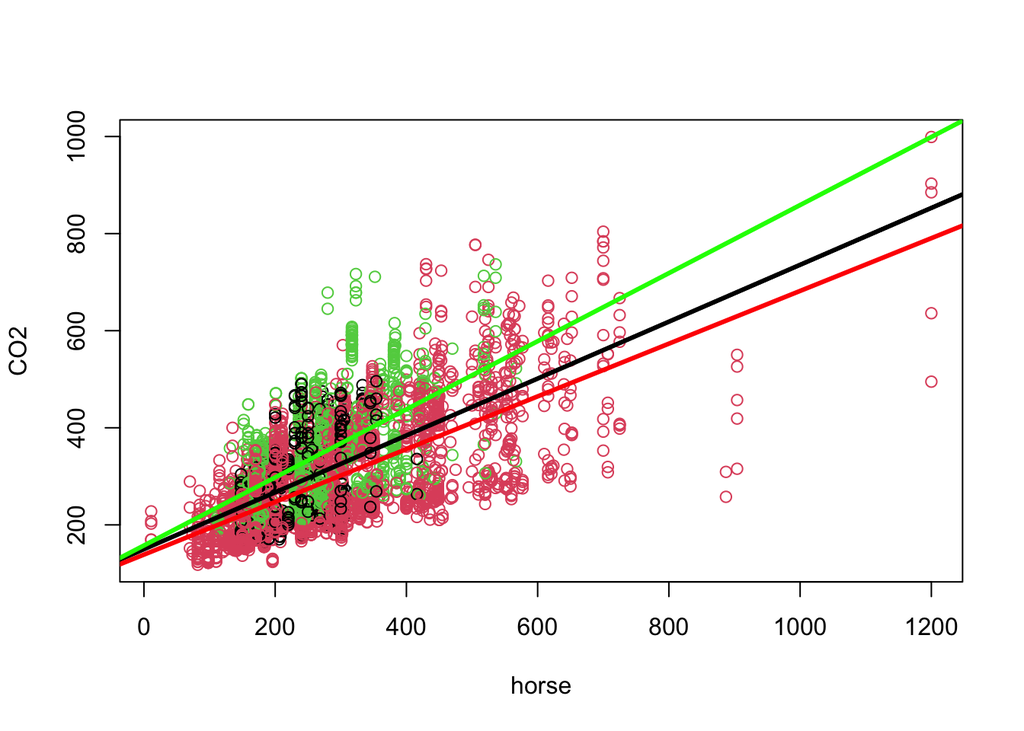

```r
plot(CO2 ~ horse, data = epa2015, col = type)

int_coef = summary(co2_int)$coef[,1]

int_both    = int_coef[1]
int_car     = int_coef[1] + int_coef[3]
int_truck   = int_coef[1] + int_coef[4]

slope_both  = int_coef[2]
slope_car   = int_coef[2] + int_coef[5]
slope_truck = int_coef[2] + int_coef[6]

abline(int_both, slope_both, lwd = 3, col = "black")
abline(int_car, slope_car, lwd = 3, col = "red")
abline(int_truck, slope_truck, lwd = 3, col = "green")
```

Create a fitted vs residuals plot for this model. Do you believe the constant variance assumption has been violated?

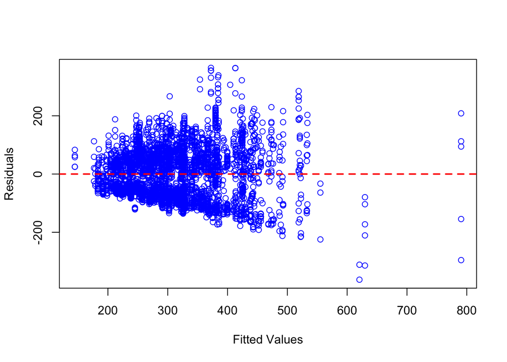

```r
plot(fitted(co2_int),resid(co2_int),col="blue",xlab="Fitted Values",ylab="Residuals")
abline(h=0,lty=2,col="red",lwd=2)
```

The constant variance assumption seems to have been violated.

**(b)** Fit the same model as **(a)** but with a logged response. Create a fitted vs residuals plot for this model. Compare to the previous. Do you believe the constant variance assumption has been violated? Any other assumptions?

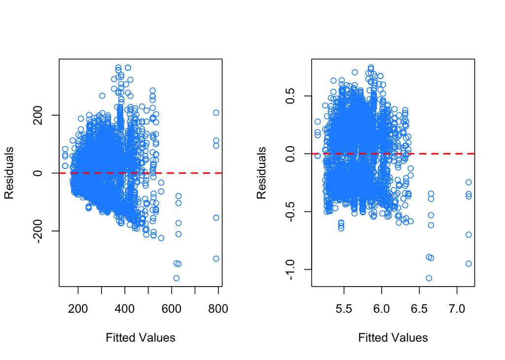

```r
par(mfrow=c(1,2))
co2_log = lm(log(CO2)~horse*type,data=epa2015)
plot(fitted(co2_int), resid(co2_int), col = "dodgerblue", xlab = "Fitted Values", ylab = "Residuals")
abline(h = 0, lty = 2, col = "red", lwd = 2)
plot(fitted(co2_log), resid(co2_log), col = "dodgerblue", xlab = "Fitted Values", ylab = "Residuals")
abline(h = 0, lty = 2, col = "red", lwd = 2)
```

The constant variance assumption is not violated for the logged response plot. The linearity assumption holds true because the residuals are mostly 0 at most fitted points.

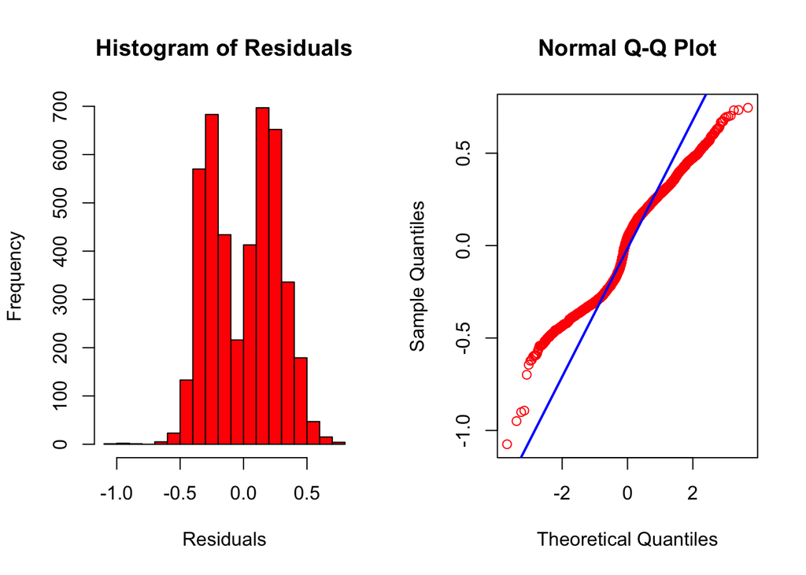

```r
par(mfrow=c(1,2))
hist(resid(co2_log), xlab   = "Residuals", main   = "Histogram of Residuals",
     col    = "red")
qqnorm(resid(co2_log), main = "Normal Q-Q Plot", col = "red")
qqline(resid(co2_log), col = "blue", lwd = 2)
```

Histogram and Q-Q plot suggest normality assumption is violated.

**(c)** Fit a model that has all of the terms from the model in **(b)** as well as a quadratic term for `horse`. Use `log(CO2)` as the response. Create a fitted vs residuals plot for this model. Compare to the previous. Comment on model assumptions.

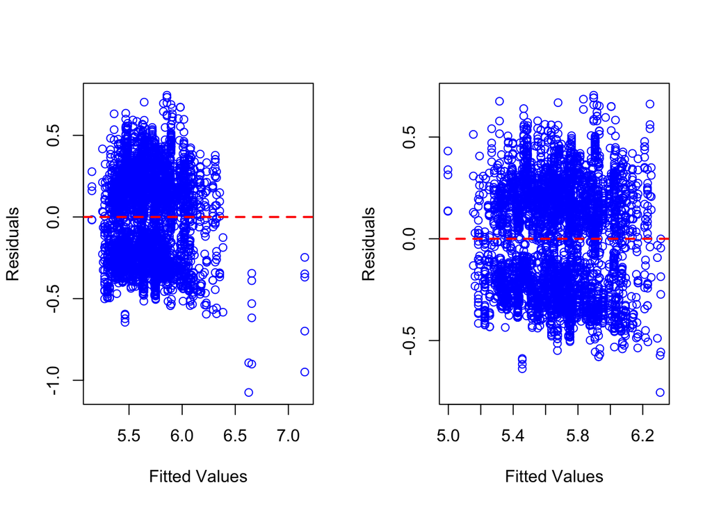

```r
par(mfrow=c(1,2))
co2_quad = lm(log(CO2)~horse*type+I(horse^2),data=epa2015)
plot(fitted(co2_log), resid(co2_log), col = "blue", xlab = "Fitted Values", ylab = "Residuals")
abline(h = 0, lty = 2, col = "red", lwd = 2)
plot(fitted(co2_quad), resid(co2_quad), col = "blue", xlab = "Fitted Values", ylab = "Residuals")
abline(h = 0, lty = 2, col = "red", lwd = 2)
```

This model is much better at holding the constant variation assumption. The linearity assumption also holds true.

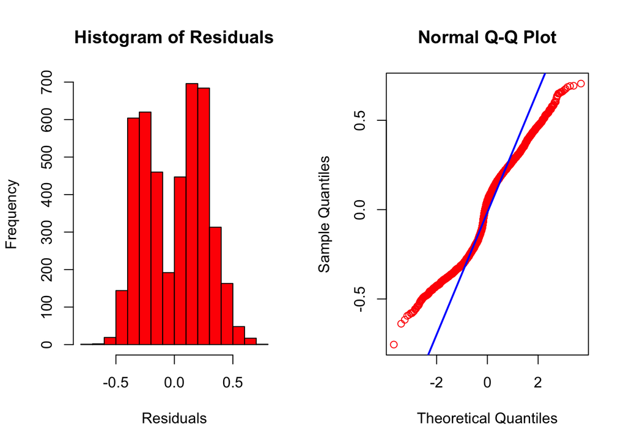

```r
par(mfrow=c(1,2))
hist(resid(co2_quad),xlab   = "Residuals", main   = "Histogram of Residuals",
     col    = "red")
qqnorm(resid(co2_quad), main = "Normal Q-Q Plot", col = "red")
qqline(resid(co2_quad), col = "blue", lwd = 2)
```

The normality assumption does not seem to hold true.

**(d)** Perform further analysis of the model fit in part **(c)**. Can you find any violations of assumptions?

```r
summary(co2_quad)
```

```
##
## Call:
## lm(formula = log(CO2) ~ horse * type + I(horse^2), data = epa2015)
##
## Residuals:
##     Min      1Q  Median      3Q     Max
## -0.7553 -0.2459  0.0506  0.2156  0.7056
##
## Coefficients:
##                  Estimate Std. Error t value Pr(>|t|)
## (Intercept)      5.07e+00   4.79e-02  105.83   <2e-16 ***
## horse            2.70e-03   1.99e-04   13.55   <2e-16 ***
## typeCar         -1.01e-01   4.92e-02   -2.06    0.040 *
## typeTruck        9.35e-02   5.53e-02    1.69    0.091 .
## I(horse^2)      -1.43e-06   1.29e-07  -11.10   <2e-16 ***
## horse:typeCar    7.33e-05   1.96e-04    0.37    0.708
## horse:typeTruck  9.63e-05   2.14e-04    0.45    0.653
## ---
## Signif. codes:  0 '***' 0.001 '**' 0.01 '*' 0.05 '.' 0.1 ' ' 1
##
## Residual standard error: 0.265 on 4404 degrees of freedom
## Multiple R-squared:  0.437,  Adjusted R-squared:  0.436
## F-statistic:  569 on 6 and 4404 DF,  p-value: <2e-16
```

The interaction term is not significant. Normality, shown in the part above, does not seem to hold true.

## Exercise 4 (Bigger Is Better?)

Consider the true model,

$$Y = 3 - 4 x + \epsilon,$$

We can simulate observations from this model. We choose a sample size of 40.

```r
n = 40
set.seed(114)
x = runif(n, 0 , 10)
y = 3 - 4 * x + rnorm(n, 0 , 3)
```

Consider two models, one small, one big. The small fits a SLR model. The big fits a polynomial model of degree 10.

```r
fit_slr = lm(y ~ x)
fit_big = lm(y ~ poly(x, 10))
```

The big model has a smaller RMSE.

```r
mean(resid(fit_slr) ^ 2)
```

```
## [1] 7.984
```

```r
mean(resid(fit_big) ^ 2)
```

```
## [1] 7.067
```

However, it is not significant when compared to the small.

```r
anova(fit_slr, fit_big)
```

```
## Analysis of Variance Table
##
## Model 1: y ~ x
## Model 2: y ~ poly(x, 10)
##   Res.Df RSS Df Sum of Sq    F Pr(>F)
## 1     38 319
## 2     29 283  9      36.7 0.42   0.91
```

By plotting the data and adding the two models, we see the the degree 10 polynomial is *very* wiggly.

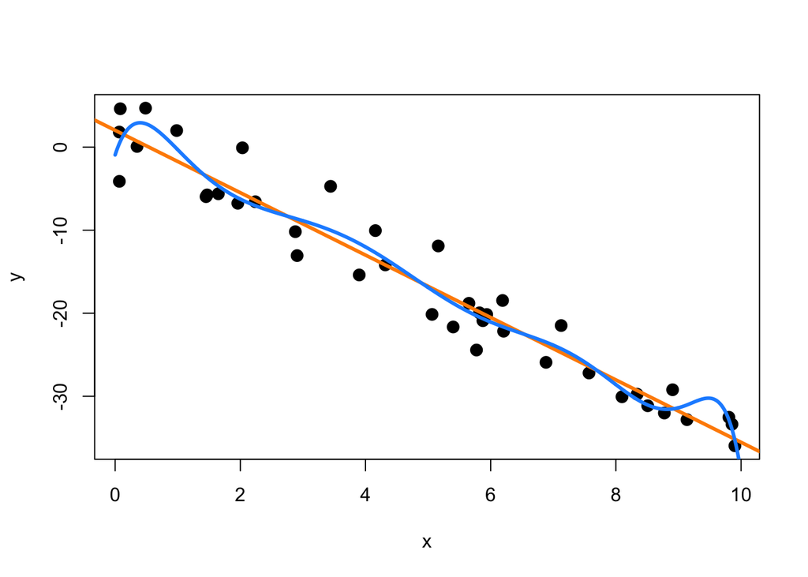

```r
plot(x, y, pch = 20, cex = 2)
abline(fit_slr, col = "darkorange", lwd = 3)
lines(seq(0, 10, 0.01),
      predict(fit_big, newdata = data.frame(x = seq(0, 10, 0.01))),
      col = 'dodgerblue', lwd = 3)
```

**(a)** Use the following code after changing `birthday` to your birthday.

```r
num_sims = 1000
rmse_slr = rep(0, num_sims)
rmse_big = rep(0, num_sims)
pval     = rep(0, num_sims)
birthday = 19990503
set.seed(birthday)
```

Repeat the above process, keeping `x` the same, then re-generating `y` and fitting the SLR and big models `1000` times. Each time, store the RMSE of each model, and the p-value for comparing the two. (In the appropriate variables defined above.)

```r
for (i in 1:num_sims){
  y = 3 - 4 * x + rnorm(n, 0 , 3)
  fit_slr = lm(y ~ x)
  fit_big = lm(y ~ poly(x, 10))
  rmse_slr[i] = mean(resid(fit_slr) ^ 2)
  rmse_big[i] = mean(resid(fit_big) ^ 2)
  pval[i] = anova(fit_slr,fit_big)$"Pr(>F)"[2]
}
```

**(b)** What proportion of the RMSEs of the SLR model are smaller than the big model?

```r
mean(rmse_slr < rmse_big)
```

```
## [1] 0
```

**(c)** What proportion of the p-values are less than 0.05?

```r
mean(pval <0.05)
```

```
## [1] 0.048
```

**(d)** Do you think bigger is better? Bigger models might be overfitting the data, meaning it is not necessarily better.